# Risk Factor Analysis

## Outcome Variable

**Outcome Variable:** whz

## Predictor Variables

**Intervention Variable:** fhtcm

**Adjustment Set:**

- arm
- W_mage
- W_fage
- meducyrs
- feducyrs
- W_mhtcm
- W_mwtkg
- W_mbmi
- single
- delta_W_mage
- delta_W_fage
- delta_meducyrs
- delta_feducyrs
- delta_W_mhtcm
- delta_W_mwtkg
- delta_W_mbmi
- delta_single

## Stratifying Variables

The analysis was stratified on these variable(s):

- agecat
- studyid
- country

## Data Summary

| agecat | studyid | country | fhtcm | n_cell | n |
| --- | --- | --- | --- | --- | --- |
| Birth | ki1000304b-SAS-CompFeed | INDIA | >=167 cm | 46 | 90 |
| Birth | ki1000304b-SAS-CompFeed | INDIA | <162 cm | 20 | 90 |
| Birth | ki1000304b-SAS-CompFeed | INDIA | [162-167) cm | 24 | 90 |
| Birth | ki1101329-Keneba | GAMBIA | >=167 cm | 710 | 1079 |
| Birth | ki1101329-Keneba | GAMBIA | <162 cm | 81 | 1079 |
| Birth | ki1101329-Keneba | GAMBIA | [162-167) cm | 288 | 1079 |
| Birth | ki1119695-PROBIT | BELARUS | >=167 cm | 11684 | 12474 |
| Birth | ki1119695-PROBIT | BELARUS | <162 cm | 168 | 12474 |
| Birth | ki1119695-PROBIT | BELARUS | [162-167) cm | 622 | 12474 |
| Birth | ki1135781-COHORTS | GUATEMALA | >=167 cm | 26 | 192 |
| Birth | ki1135781-COHORTS | GUATEMALA | <162 cm | 112 | 192 |
| Birth | ki1135781-COHORTS | GUATEMALA | [162-167) cm | 54 | 192 |
| 6 months | ki1000304b-SAS-CompFeed | INDIA | >=167 cm | 370 | 807 |
| 6 months | ki1000304b-SAS-CompFeed | INDIA | <162 cm | 193 | 807 |
| 6 months | ki1000304b-SAS-CompFeed | INDIA | [162-167) cm | 244 | 807 |
| 6 months | ki1000304b-SAS-FoodSuppl | INDIA | >=167 cm | 102 | 371 |
| 6 months | ki1000304b-SAS-FoodSuppl | INDIA | <162 cm | 148 | 371 |
| 6 months | ki1000304b-SAS-FoodSuppl | INDIA | [162-167) cm | 121 | 371 |
| 6 months | ki1101329-Keneba | GAMBIA | >=167 cm | 979 | 1510 |
| 6 months | ki1101329-Keneba | GAMBIA | <162 cm | 113 | 1510 |
| 6 months | ki1101329-Keneba | GAMBIA | [162-167) cm | 418 | 1510 |
| 6 months | ki1119695-PROBIT | BELARUS | >=167 cm | 11143 | 11892 |
| 6 months | ki1119695-PROBIT | BELARUS | <162 cm | 156 | 11892 |
| 6 months | ki1119695-PROBIT | BELARUS | [162-167) cm | 593 | 11892 |
| 6 months | ki1135781-COHORTS | GUATEMALA | >=167 cm | 44 | 336 |
| 6 months | ki1135781-COHORTS | GUATEMALA | <162 cm | 198 | 336 |
| 6 months | ki1135781-COHORTS | GUATEMALA | [162-167) cm | 94 | 336 |
| 24 months | ki1101329-Keneba | GAMBIA | >=167 cm | 823 | 1298 |
| 24 months | ki1101329-Keneba | GAMBIA | <162 cm | 96 | 1298 |
| 24 months | ki1101329-Keneba | GAMBIA | [162-167) cm | 379 | 1298 |
| 24 months | ki1119695-PROBIT | BELARUS | >=167 cm | 3387 | 3609 |
| 24 months | ki1119695-PROBIT | BELARUS | <162 cm | 52 | 3609 |
| 24 months | ki1119695-PROBIT | BELARUS | [162-167) cm | 170 | 3609 |
| 24 months | ki1135781-COHORTS | GUATEMALA | >=167 cm | 72 | 532 |
| 24 months | ki1135781-COHORTS | GUATEMALA | <162 cm | 311 | 532 |
| 24 months | ki1135781-COHORTS | GUATEMALA | [162-167) cm | 149 | 532 |

The following strata were considered:

- agecat: 24 months, studyid: ki1101329-Keneba, country: GAMBIA
- agecat: 24 months, studyid: ki1119695-PROBIT, country: BELARUS
- agecat: 24 months, studyid: ki1135781-COHORTS, country: GUATEMALA
- agecat: 6 months, studyid: ki1000304b-SAS-CompFeed, country: INDIA
- agecat: 6 months, studyid: ki1000304b-SAS-FoodSuppl, country: INDIA
- agecat: 6 months, studyid: ki1101329-Keneba, country: GAMBIA
- agecat: 6 months, studyid: ki1119695-PROBIT, country: BELARUS
- agecat: 6 months, studyid: ki1135781-COHORTS, country: GUATEMALA
- agecat: Birth, studyid: ki1000304b-SAS-CompFeed, country: INDIA
- agecat: Birth, studyid: ki1101329-Keneba, country: GAMBIA
- agecat: Birth, studyid: ki1119695-PROBIT, country: BELARUS
- agecat: Birth, studyid: ki1135781-COHORTS, country: GUATEMALA

## Methods Detail

We’re interested in the causal parameters $E[Y_a]$ for all values of $a \in \mathcal{A}$. These parameters represent the mean outcome if, possibly contrary to fact, we intervened to set all units to have $A=a$. Under the randomization and positivity assumptions, these are identified by the statistical parameters $\psi_a=E_W[E_{Y|A,W}(Y|A=a,W)]$. In addition, we’re interested in the mean of $Y$, $E[Y]$ under no intervention (the observed mean). We will estimate these parameters by using SuperLearner to fit the relevant likelihood factors – $E_{Y|A,W}(Y|A=a,W)$ and $p(A=a|W)$, and then updating our likelihood fit using a joint TMLE.

For unadjusted analyses ($W=\{\}$), initial likelihoods were estimated using Lrnr_glm to estimate the simple $E(Y|A)$ and Lrnr_mean to estimate $p(A)$. For adjusted analyses, a small library containing Lrnr_glmnet, Lrnr_xgboost, and Lrnr_mean was used.

Having estimated these parameters, we will then use the delta method to estimate relative risks and attributable risks relative to a prespecified baseline level of $A$.

# Results Detail

## Results Plots

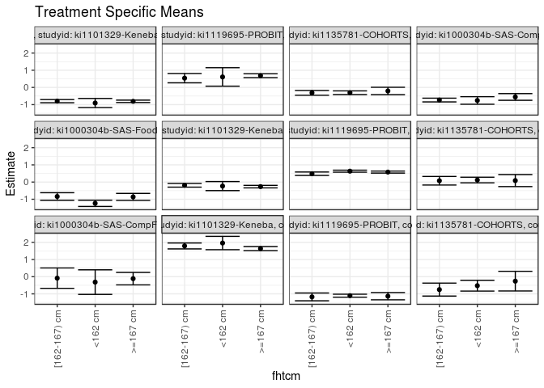

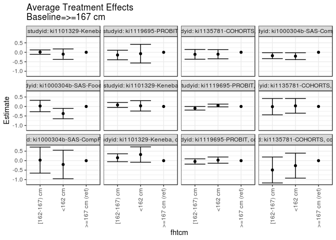

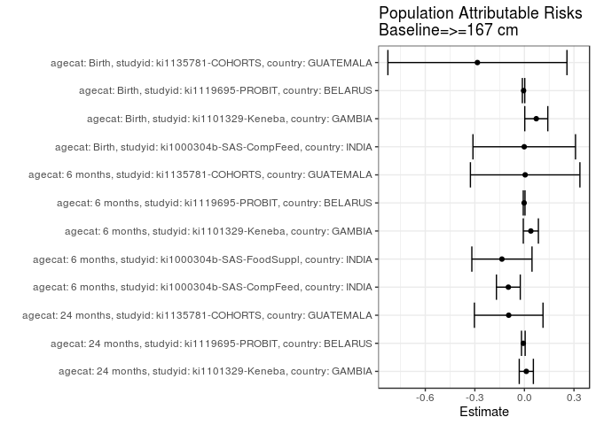

## Results Table

### Parameter: TSM

| agecat | studyid | country | intervention_level | baseline_level | estimate | ci_lower | ci_upper |
| --- | --- | --- | --- | --- | --- | --- | --- |
| Birth | ki1000304b-SAS-CompFeed | INDIA | >=167 cm | NA | -0.1145847 | -0.4775432 | 0.2483737 |
| Birth | ki1000304b-SAS-CompFeed | INDIA | <162 cm | NA | -0.3161775 | -1.0310714 | 0.3987165 |
| Birth | ki1000304b-SAS-CompFeed | INDIA | [162-167) cm | NA | -0.0862460 | -0.6785350 | 0.5060430 |
| Birth | ki1101329-Keneba | GAMBIA | >=167 cm | NA | 1.6346272 | 1.5160912 | 1.7531633 |
| Birth | ki1101329-Keneba | GAMBIA | <162 cm | NA | 1.9576644 | 1.5696803 | 2.3456484 |
| Birth | ki1101329-Keneba | GAMBIA | [162-167) cm | NA | 1.7880547 | 1.6153166 | 1.9607928 |
| Birth | ki1119695-PROBIT | BELARUS | >=167 cm | NA | -1.1339549 | -1.3451852 | -0.9227246 |
| Birth | ki1119695-PROBIT | BELARUS | <162 cm | NA | -1.1055252 | -1.1916616 | -1.0193887 |
| Birth | ki1119695-PROBIT | BELARUS | [162-167) cm | NA | -1.1766984 | -1.4039340 | -0.9494629 |
| Birth | ki1135781-COHORTS | GUATEMALA | >=167 cm | NA | -0.2606156 | -0.8328706 | 0.3116394 |
| Birth | ki1135781-COHORTS | GUATEMALA | <162 cm | NA | -0.5240821 | -0.8391249 | -0.2090393 |
| Birth | ki1135781-COHORTS | GUATEMALA | [162-167) cm | NA | -0.7515102 | -1.1279593 | -0.3750611 |
| 6 months | ki1000304b-SAS-CompFeed | INDIA | >=167 cm | NA | -0.5530680 | -0.7475827 | -0.3585533 |
| 6 months | ki1000304b-SAS-CompFeed | INDIA | <162 cm | NA | -0.7584375 | -0.9773442 | -0.5395308 |
| 6 months | ki1000304b-SAS-CompFeed | INDIA | [162-167) cm | NA | -0.7331331 | -0.8416653 | -0.6246009 |
| 6 months | ki1000304b-SAS-FoodSuppl | INDIA | >=167 cm | NA | -0.8636346 | -1.0673831 | -0.6598861 |
| 6 months | ki1000304b-SAS-FoodSuppl | INDIA | <162 cm | NA | -1.2373705 | -1.4197039 | -1.0550370 |
| 6 months | ki1000304b-SAS-FoodSuppl | INDIA | [162-167) cm | NA | -0.8390757 | -1.0581835 | -0.6199679 |
| 6 months | ki1101329-Keneba | GAMBIA | >=167 cm | NA | -0.2661167 | -0.3399065 | -0.1923270 |
| 6 months | ki1101329-Keneba | GAMBIA | <162 cm | NA | -0.2339797 | -0.4973188 | 0.0293594 |
| 6 months | ki1101329-Keneba | GAMBIA | [162-167) cm | NA | -0.1861722 | -0.2941698 | -0.0781746 |
| 6 months | ki1119695-PROBIT | BELARUS | >=167 cm | NA | 0.5808940 | 0.5217496 | 0.6400384 |
| 6 months | ki1119695-PROBIT | BELARUS | <162 cm | NA | 0.6330219 | 0.5737214 | 0.6923225 |
| 6 months | ki1119695-PROBIT | BELARUS | [162-167) cm | NA | 0.4855579 | 0.3870128 | 0.5841029 |
| 6 months | ki1135781-COHORTS | GUATEMALA | >=167 cm | NA | 0.0863501 | -0.2643829 | 0.4370831 |
| 6 months | ki1135781-COHORTS | GUATEMALA | <162 cm | NA | 0.1190760 | -0.0442482 | 0.2824002 |
| 6 months | ki1135781-COHORTS | GUATEMALA | [162-167) cm | NA | 0.0764830 | -0.1721543 | 0.3251203 |
| 24 months | ki1101329-Keneba | GAMBIA | >=167 cm | NA | -0.8078377 | -0.8778791 | -0.7377963 |
| 24 months | ki1101329-Keneba | GAMBIA | <162 cm | NA | -0.9063853 | -1.1717826 | -0.6409881 |
| 24 months | ki1101329-Keneba | GAMBIA | [162-167) cm | NA | -0.7991258 | -0.8919797 | -0.7062720 |
| 24 months | ki1119695-PROBIT | BELARUS | >=167 cm | NA | 0.6839186 | 0.5717139 | 0.7961232 |
| 24 months | ki1119695-PROBIT | BELARUS | <162 cm | NA | 0.6108778 | 0.0745022 | 1.1472535 |
| 24 months | ki1119695-PROBIT | BELARUS | [162-167) cm | NA | 0.5407108 | 0.2681974 | 0.8132241 |
| 24 months | ki1135781-COHORTS | GUATEMALA | >=167 cm | NA | -0.2052062 | -0.4211857 | 0.0107732 |
| 24 months | ki1135781-COHORTS | GUATEMALA | <162 cm | NA | -0.3077462 | -0.4148489 | -0.2006435 |
| 24 months | ki1135781-COHORTS | GUATEMALA | [162-167) cm | NA | -0.3144701 | -0.4541707 | -0.1747695 |

### Parameter: E(Y)

| agecat | studyid | country | intervention_level | baseline_level | estimate | ci_lower | ci_upper |
| --- | --- | --- | --- | --- | --- | --- | --- |
| Birth | ki1000304b-SAS-CompFeed | INDIA | NA | NA | -0.1156667 | -0.4507658 | 0.2194325 |
| Birth | ki1101329-Keneba | GAMBIA | NA | NA | 1.7064875 | 1.6129215 | 1.8000534 |
| Birth | ki1119695-PROBIT | BELARUS | NA | NA | -1.1390957 | -1.3485249 | -0.9296665 |
| Birth | ki1135781-COHORTS | GUATEMALA | NA | NA | -0.5450521 | -0.7653906 | -0.3247135 |
| 6 months | ki1000304b-SAS-CompFeed | INDIA | NA | NA | -0.6502726 | -0.7957520 | -0.5047932 |
| 6 months | ki1000304b-SAS-FoodSuppl | INDIA | NA | NA | -0.9997844 | -1.1172238 | -0.8823449 |
| 6 months | ki1101329-Keneba | GAMBIA | NA | NA | -0.2272250 | -0.2854487 | -0.1690012 |
| 6 months | ki1119695-PROBIT | BELARUS | NA | NA | 0.5791961 | 0.5216790 | 0.6367132 |
| 6 months | ki1135781-COHORTS | GUATEMALA | NA | NA | 0.0909226 | -0.0348636 | 0.2167089 |
| 24 months | ki1101329-Keneba | GAMBIA | NA | NA | -0.7963776 | -0.8498028 | -0.7429525 |
| 24 months | ki1119695-PROBIT | BELARUS | NA | NA | 0.6773192 | 0.5626171 | 0.7920213 |
| 24 months | ki1135781-COHORTS | GUATEMALA | NA | NA | -0.3002632 | -0.3780672 | -0.2224591 |

### Parameter: ATE

| agecat | studyid | country | intervention_level | baseline_level | estimate | ci_lower | ci_upper |
| --- | --- | --- | --- | --- | --- | --- | --- |
| Birth | ki1000304b-SAS-CompFeed | INDIA | >=167 cm | >=167 cm | 0.0000000 | 0.0000000 | 0.0000000 |
| Birth | ki1000304b-SAS-CompFeed | INDIA | <162 cm | >=167 cm | -0.2015927 | -0.9535646 | 0.5503792 |
| Birth | ki1000304b-SAS-CompFeed | INDIA | [162-167) cm | >=167 cm | 0.0283387 | -0.6579085 | 0.7145860 |
| Birth | ki1101329-Keneba | GAMBIA | >=167 cm | >=167 cm | 0.0000000 | 0.0000000 | 0.0000000 |
| Birth | ki1101329-Keneba | GAMBIA | <162 cm | >=167 cm | 0.3230372 | -0.0824770 | 0.7285513 |
| Birth | ki1101329-Keneba | GAMBIA | [162-167) cm | >=167 cm | 0.1534275 | -0.0561047 | 0.3629597 |
| Birth | ki1119695-PROBIT | BELARUS | >=167 cm | >=167 cm | 0.0000000 | 0.0000000 | 0.0000000 |
| Birth | ki1119695-PROBIT | BELARUS | <162 cm | >=167 cm | 0.0284297 | -0.1355720 | 0.1924315 |
| Birth | ki1119695-PROBIT | BELARUS | [162-167) cm | >=167 cm | -0.0427435 | -0.1829931 | 0.0975061 |
| Birth | ki1135781-COHORTS | GUATEMALA | >=167 cm | >=167 cm | 0.0000000 | 0.0000000 | 0.0000000 |
| Birth | ki1135781-COHORTS | GUATEMALA | <162 cm | >=167 cm | -0.2634665 | -0.9219437 | 0.3950107 |
| Birth | ki1135781-COHORTS | GUATEMALA | [162-167) cm | >=167 cm | -0.4908947 | -1.1737629 | 0.1919736 |
| 6 months | ki1000304b-SAS-CompFeed | INDIA | >=167 cm | >=167 cm | 0.0000000 | 0.0000000 | 0.0000000 |
| 6 months | ki1000304b-SAS-CompFeed | INDIA | <162 cm | >=167 cm | -0.2053695 | -0.3855721 | -0.0251669 |
| 6 months | ki1000304b-SAS-CompFeed | INDIA | [162-167) cm | >=167 cm | -0.1800651 | -0.3371105 | -0.0230196 |
| 6 months | ki1000304b-SAS-FoodSuppl | INDIA | >=167 cm | >=167 cm | 0.0000000 | 0.0000000 | 0.0000000 |
| 6 months | ki1000304b-SAS-FoodSuppl | INDIA | <162 cm | >=167 cm | -0.3737359 | -0.6472171 | -0.1002546 |
| 6 months | ki1000304b-SAS-FoodSuppl | INDIA | [162-167) cm | >=167 cm | 0.0245589 | -0.2760838 | 0.3252016 |
| 6 months | ki1101329-Keneba | GAMBIA | >=167 cm | >=167 cm | 0.0000000 | 0.0000000 | 0.0000000 |
| 6 months | ki1101329-Keneba | GAMBIA | <162 cm | >=167 cm | 0.0321371 | -0.2414798 | 0.3057539 |
| 6 months | ki1101329-Keneba | GAMBIA | [162-167) cm | >=167 cm | 0.0799445 | -0.0507552 | 0.2106442 |
| 6 months | ki1119695-PROBIT | BELARUS | >=167 cm | >=167 cm | 0.0000000 | 0.0000000 | 0.0000000 |
| 6 months | ki1119695-PROBIT | BELARUS | <162 cm | >=167 cm | 0.0521279 | -0.0203320 | 0.1245878 |
| 6 months | ki1119695-PROBIT | BELARUS | [162-167) cm | >=167 cm | -0.0953361 | -0.1902607 | -0.0004116 |
| 6 months | ki1135781-COHORTS | GUATEMALA | >=167 cm | >=167 cm | 0.0000000 | 0.0000000 | 0.0000000 |
| 6 months | ki1135781-COHORTS | GUATEMALA | <162 cm | >=167 cm | 0.0327259 | -0.3549420 | 0.4203938 |
| 6 months | ki1135781-COHORTS | GUATEMALA | [162-167) cm | >=167 cm | -0.0098671 | -0.4396709 | 0.4199368 |
| 24 months | ki1101329-Keneba | GAMBIA | >=167 cm | >=167 cm | 0.0000000 | 0.0000000 | 0.0000000 |
| 24 months | ki1101329-Keneba | GAMBIA | <162 cm | >=167 cm | -0.0985476 | -0.3732956 | 0.1762004 |
| 24 months | ki1101329-Keneba | GAMBIA | [162-167) cm | >=167 cm | 0.0087119 | -0.1079386 | 0.1253624 |
| 24 months | ki1119695-PROBIT | BELARUS | >=167 cm | >=167 cm | 0.0000000 | 0.0000000 | 0.0000000 |
| 24 months | ki1119695-PROBIT | BELARUS | <162 cm | >=167 cm | -0.0730408 | -0.5650907 | 0.4190092 |
| 24 months | ki1119695-PROBIT | BELARUS | [162-167) cm | >=167 cm | -0.1432078 | -0.3944942 | 0.1080786 |
| 24 months | ki1135781-COHORTS | GUATEMALA | >=167 cm | >=167 cm | 0.0000000 | 0.0000000 | 0.0000000 |
| 24 months | ki1135781-COHORTS | GUATEMALA | <162 cm | >=167 cm | -0.1025400 | -0.3436322 | 0.1385522 |
| 24 months | ki1135781-COHORTS | GUATEMALA | [162-167) cm | >=167 cm | -0.1092638 | -0.3665896 | 0.1480619 |

### Parameter: PAR

| agecat | studyid | country | intervention_level | baseline_level | estimate | ci_lower | ci_upper |
| --- | --- | --- | --- | --- | --- | --- | --- |
| Birth | ki1000304b-SAS-CompFeed | INDIA | >=167 cm | NA | -0.0010819 | -0.3114889 | 0.3093251 |
| Birth | ki1101329-Keneba | GAMBIA | >=167 cm | NA | 0.0718603 | 0.0021501 | 0.1415705 |
| Birth | ki1119695-PROBIT | BELARUS | >=167 cm | NA | -0.0051408 | -0.0123893 | 0.0021077 |
| Birth | ki1135781-COHORTS | GUATEMALA | >=167 cm | NA | -0.2844365 | -0.8264245 | 0.2575515 |
| 6 months | ki1000304b-SAS-CompFeed | INDIA | >=167 cm | NA | -0.0972046 | -0.1693575 | -0.0250516 |
| 6 months | ki1000304b-SAS-FoodSuppl | INDIA | >=167 cm | NA | -0.1361498 | -0.3182677 | 0.0459682 |
| 6 months | ki1101329-Keneba | GAMBIA | >=167 cm | NA | 0.0388918 | -0.0068015 | 0.0845850 |
| 6 months | ki1119695-PROBIT | BELARUS | >=167 cm | NA | -0.0016979 | -0.0070015 | 0.0036057 |
| 6 months | ki1135781-COHORTS | GUATEMALA | >=167 cm | NA | 0.0045725 | -0.3268533 | 0.3359984 |
| 24 months | ki1101329-Keneba | GAMBIA | >=167 cm | NA | 0.0114601 | -0.0313056 | 0.0542258 |
| 24 months | ki1119695-PROBIT | BELARUS | >=167 cm | NA | -0.0065994 | -0.0176521 | 0.0044533 |
| 24 months | ki1135781-COHORTS | GUATEMALA | >=167 cm | NA | -0.0950569 | -0.3027055 | 0.1125917 |